# PD3 Testy knn

Jadwiga Słowik

April 27, 2017

# Wstęp

Ów raport stanowi sprawdzenie poprawności działania zaimplementowanego algorytmu `knn`. Poniżej zostaną przedstawione wyniki działania algorytmu dla wybranych zbiorów testowych w $\mathbb{R}^2$, a następnie zostaną one porównanie z wynikami zwracanymi przez daną funkcję `knn_do_porownan`.

Punkty mające tę samą etykietę oznaczamy za pomocą tego samego symbolu i koloru.

# Test $1$ – dwa ,,skupiska’’ punktow

Mamy dwie możliwe etykiety $1$ i $2$.

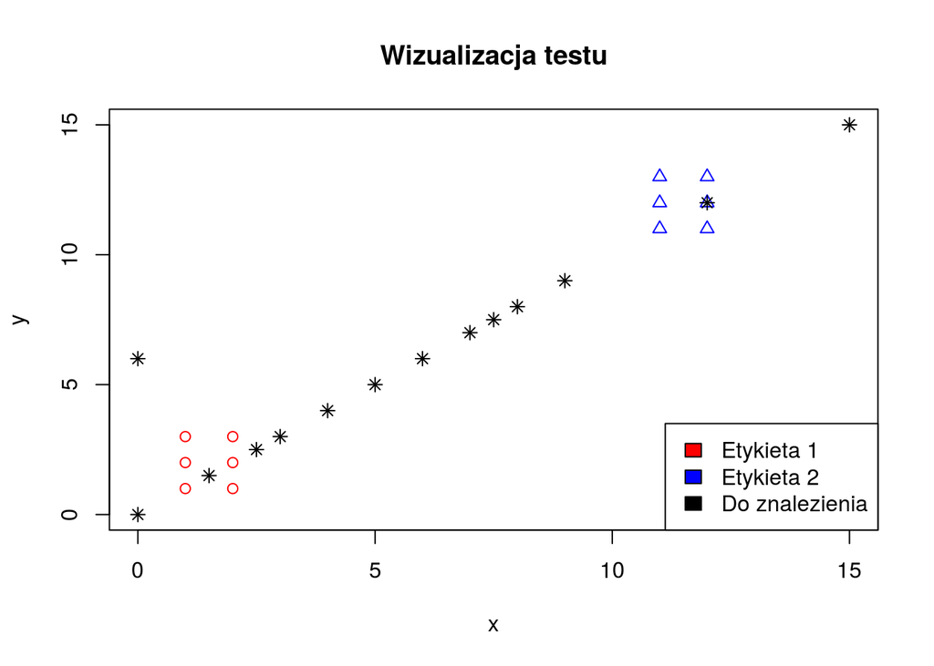

## Odpowiedzi dla `p = 2` i `k = 2`

Klasyfikacja przebiegła w następujący sposób:

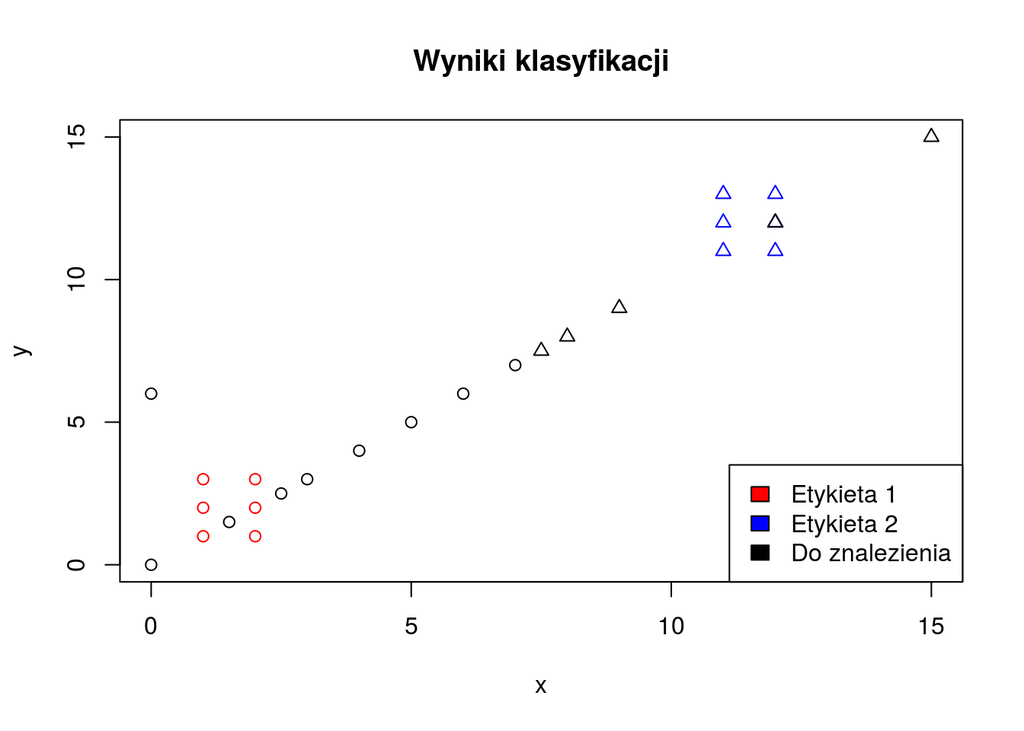

Porównajmy wyniki funkcji `knn` i `knn_do_porownan`:

| x | y | knn_wyn | knn_do_porownan_wyn |
| --- | --- | --- | --- |
| 0.0 | 0.0 | 1 | 1 |
| 1.5 | 1.5 | 1 | 1 |
| 2.5 | 2.5 | 1 | 1 |
| 3.0 | 3.0 | 1 | 1 |
| 4.0 | 4.0 | 1 | 1 |
| 5.0 | 5.0 | 1 | 1 |
| 6.0 | 6.0 | 1 | 1 |
| 7.0 | 7.0 | 2 | 1 |
| 7.5 | 7.5 | 2 | 2 |
| 8.0 | 8.0 | 2 | 2 |
| 9.0 | 9.0 | 2 | 2 |
| 12.0 | 12.0 | 2 | 2 |
| 15.0 | 15.0 | 2 | 2 |
| 0.0 | 6.0 | 1 | 1 |

Zauważmy, że wyniki są takie same z wyjątkiem punktu `(7, 7)`. Jednakże, warto zwrócić uwagę na to, że w teście bierzemy pod uwagę dokładnie $2$ punkty przy obliczaniu mody i w tym przypadku będą to dwa różne punkty, dlatego zostanie wybrany jeden losowy.

## Odpowiedzi dla `p=3` i `k=3`

Klasyfikacja przebiegła w następujący sposób:

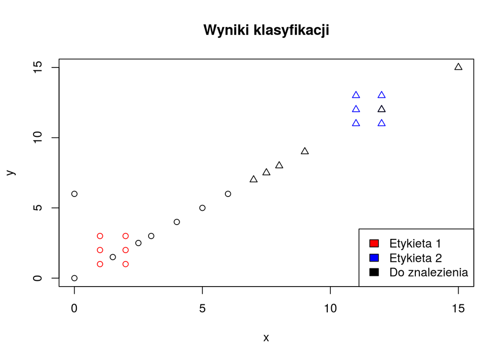

Porównajmy wyniki funkcji `knn` i `knn_do_porownan`:

| x | y | knn_wyn | knn_do_porownan_wyn |
| --- | --- | --- | --- |
| 0.0 | 0.0 | 1 | 1 |
| 1.5 | 1.5 | 1 | 1 |
| 2.5 | 2.5 | 1 | 1 |
| 3.0 | 3.0 | 1 | 1 |
| 4.0 | 4.0 | 1 | 1 |
| 5.0 | 5.0 | 1 | 1 |
| 6.0 | 6.0 | 1 | 1 |
| 7.0 | 7.0 | 2 | 2 |
| 7.5 | 7.5 | 2 | 2 |
| 8.0 | 8.0 | 2 | 2 |
| 9.0 | 9.0 | 2 | 2 |
| 12.0 | 12.0 | 2 | 2 |
| 15.0 | 15.0 | 2 | 2 |
| 0.0 | 6.0 | 1 | 1 |

# Test `2` – ,,trzy wzory’’

Mamy $3$ możliwe etykiety.

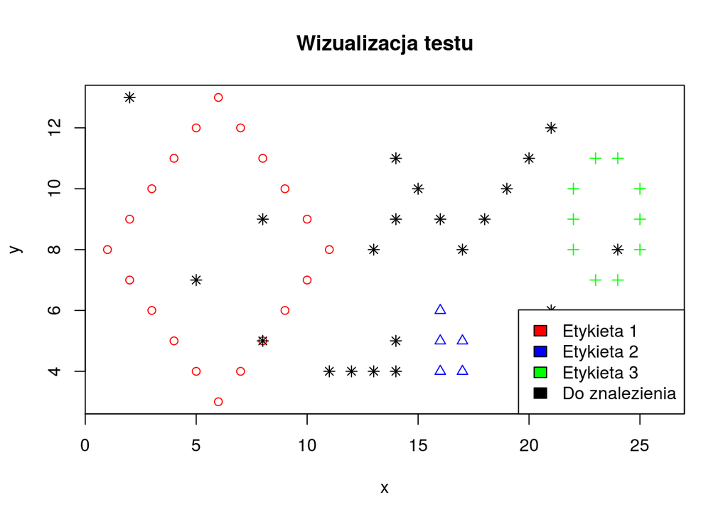

## Odpowiedzi dla `p=1`, `k=1`

Klasyfikacja przebiegła w następujący sposób:

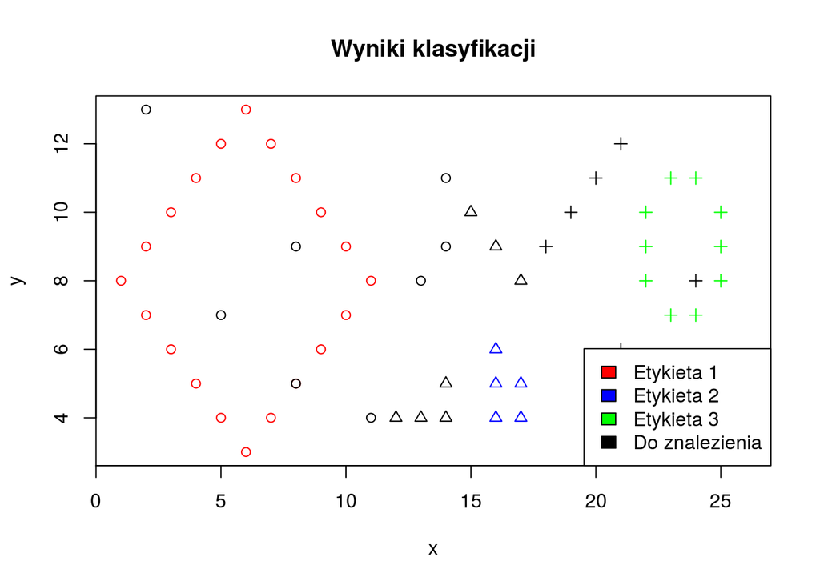

Porównajmy wyniki funkcji `knn` i `knn_do_porownan`:

| x | y | knn_wyn | knn_do_porownan_wyn |
| --- | --- | --- | --- |
| 2 | 13 | 1 | 1 |
| 5 | 7 | 1 | 1 |
| 8 | 9 | 1 | 1 |
| 14 | 11 | 1 | 1 |
| 13 | 4 | 2 | 2 |
| 8 | 5 | 1 | 1 |
| 21 | 6 | 3 | 3 |
| 24 | 8 | 3 | 3 |
| 26 | 4 | 3 | 3 |
| 14 | 9 | 1 | 1 |
| 13 | 8 | 1 | 1 |
| 15 | 10 | 2 | 2 |
| 16 | 9 | 2 | 2 |
| 17 | 8 | 2 | 2 |
| 18 | 9 | 3 | 3 |
| 19 | 10 | 3 | 3 |
| 20 | 11 | 3 | 3 |
| 21 | 12 | 3 | 3 |
| 14 | 4 | 2 | 2 |
| 14 | 5 | 2 | 2 |
| 11 | 4 | 1 | 1 |
| 12 | 4 | 2 | 2 |

## Odpowiedzi dla `p=1`, `k=2`

Klasyfikacja przebiegła w następujący sposób:

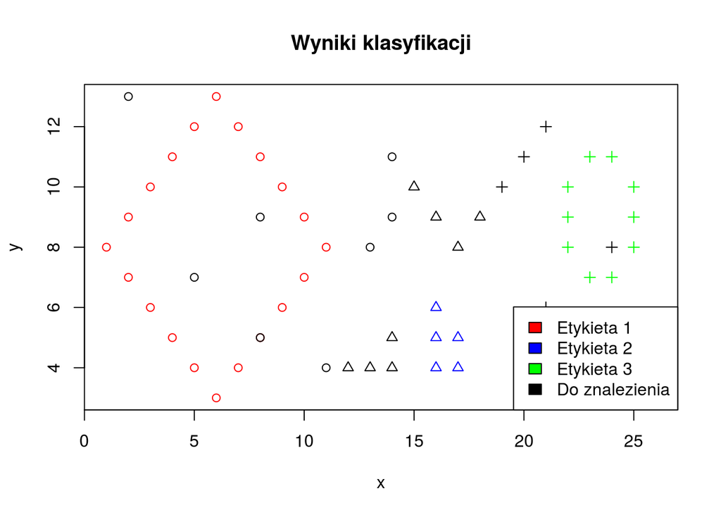

Porównajmy wyniki funkcji `knn` i `knn_do_porownan`:

| x | y | knn_wyn | knn_do_porownan_wyn |
| --- | --- | --- | --- |
| 2 | 13 | 1 | 1 |
| 5 | 7 | 1 | 1 |
| 8 | 9 | 1 | 1 |
| 14 | 11 | 1 | 1 |
| 13 | 4 | 2 | 2 |
| 8 | 5 | 1 | 1 |
| 21 | 6 | 3 | 3 |
| 24 | 8 | 3 | 3 |
| 26 | 4 | 3 | 3 |
| 14 | 9 | 1 | 1 |
| 13 | 8 | 1 | 1 |
| 15 | 10 | 1 | 1 |
| 16 | 9 | 2 | 2 |
| 17 | 8 | 2 | 2 |
| 18 | 9 | 2 | 3 |
| 19 | 10 | 3 | 3 |
| 20 | 11 | 3 | 3 |
| 21 | 12 | 3 | 3 |
| 14 | 4 | 2 | 2 |
| 14 | 5 | 2 | 2 |
| 11 | 4 | 1 | 1 |
| 12 | 4 | 1 | 2 |

## Odpowiedzi dla `p=1`, `k=3`

Klasyfikacja przebiegła w następujący sposób:

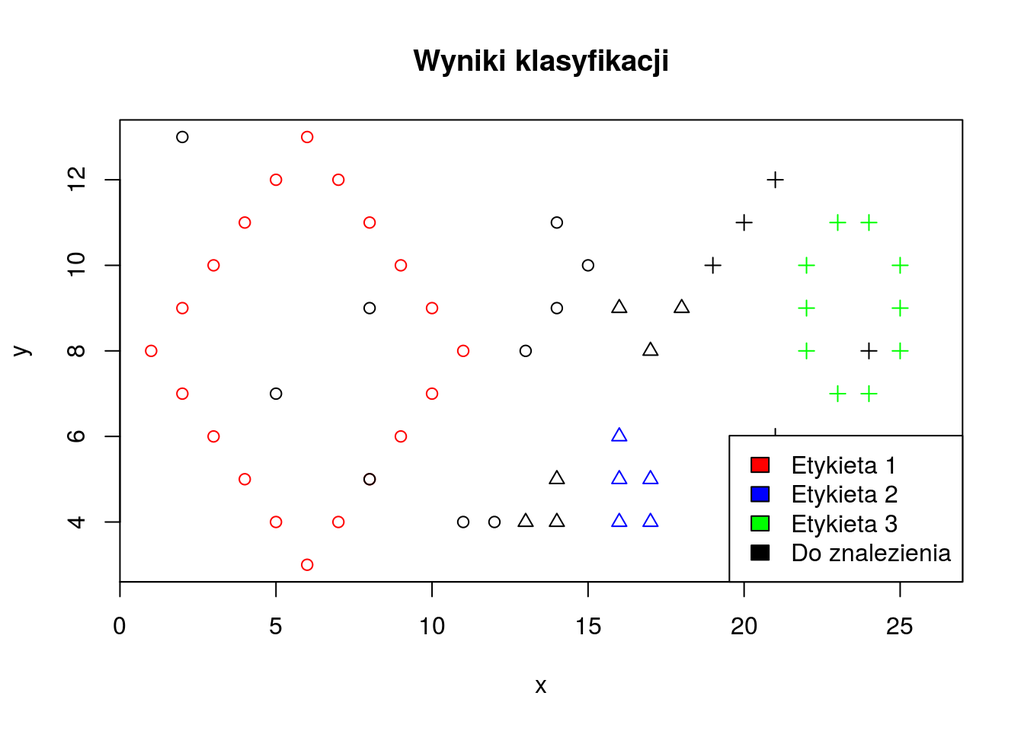

Porównajmy wyniki funkcji `knn` i `knn_do_porownan`:

| x | y | knn_wyn | knn_do_porownan_wyn |
| --- | --- | --- | --- |
| 2 | 13 | 1 | 1 |
| 5 | 7 | 1 | 1 |
| 8 | 9 | 1 | 1 |
| 14 | 11 | 1 | 1 |
| 13 | 4 | 2 | 2 |
| 8 | 5 | 1 | 1 |
| 21 | 6 | 3 | 3 |
| 24 | 8 | 3 | 3 |
| 26 | 4 | 3 | 3 |
| 14 | 9 | 1 | 1 |
| 13 | 8 | 1 | 1 |
| 15 | 10 | 1 | 1 |
| 16 | 9 | 2 | 2 |
| 17 | 8 | 2 | 2 |
| 18 | 9 | 2 | 2 |
| 19 | 10 | 3 | 3 |
| 20 | 11 | 3 | 3 |
| 21 | 12 | 3 | 3 |
| 14 | 4 | 2 | 2 |
| 14 | 5 | 2 | 2 |
| 11 | 4 | 1 | 1 |
| 12 | 4 | 1 | 1 |

## Odpowiedzi dla `p=1`, `k=8`

Klasyfikacja przebiegła w następujący sposób:

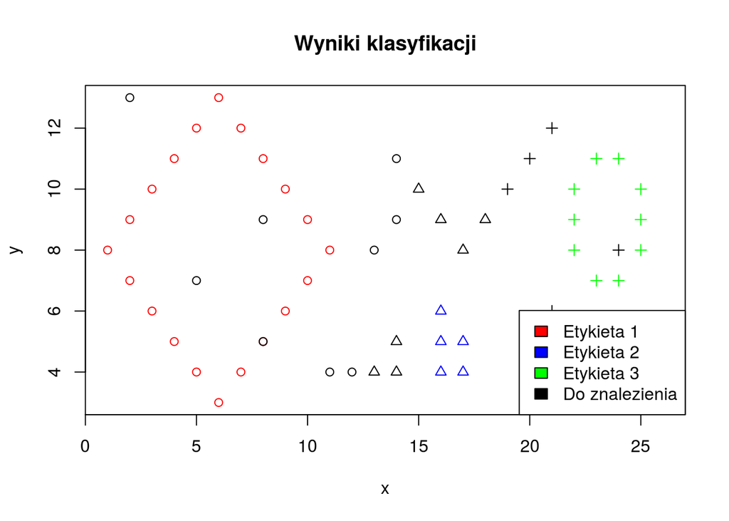

Porównajmy wyniki funkcji `knn` i `knn_do_porownan`:

| x | y | knn_wyn | knn_do_porownan_wyn |
| --- | --- | --- | --- |
| 2 | 13 | 1 | 1 |
| 5 | 7 | 1 | 1 |
| 8 | 9 | 1 | 1 |
| 14 | 11 | 1 | 1 |
| 13 | 4 | 2 | 2 |
| 8 | 5 | 1 | 1 |
| 21 | 6 | 3 | 3 |
| 24 | 8 | 3 | 3 |
| 26 | 4 | 3 | 3 |
| 14 | 9 | 2 | 1 |
| 13 | 8 | 1 | 1 |
| 15 | 10 | 2 | 2 |
| 16 | 9 | 2 | 2 |
| 17 | 8 | 2 | 2 |
| 18 | 9 | 2 | 2 |
| 19 | 10 | 3 | 3 |
| 20 | 11 | 3 | 3 |
| 21 | 12 | 3 | 3 |
| 14 | 4 | 2 | 2 |
| 14 | 5 | 2 | 2 |
| 11 | 4 | 1 | 1 |
| 12 | 4 | 1 | 1 |

## Odpowiedzi dla `p=2`, `k=3`

Klasyfikacja przebiegła w następujący sposób:

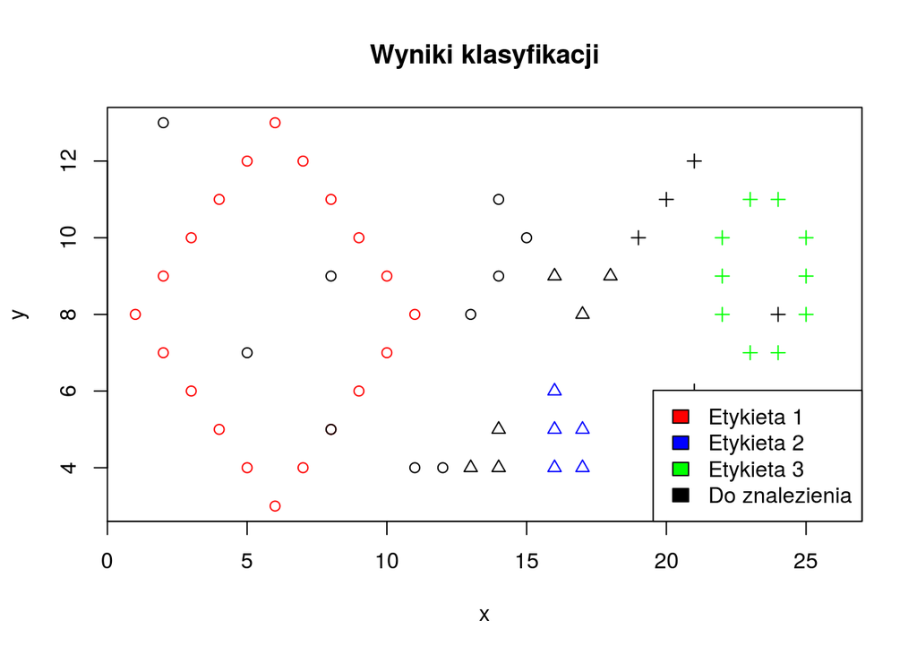

Porównajmy wyniki funkcji `knn` i `knn_do_porownan`:

| x | y | knn_wyn | knn_do_porownan_wyn |
| --- | --- | --- | --- |
| 2 | 13 | 1 | 1 |
| 5 | 7 | 1 | 1 |
| 8 | 9 | 1 | 1 |
| 14 | 11 | 1 | 1 |
| 13 | 4 | 2 | 2 |
| 8 | 5 | 1 | 1 |
| 21 | 6 | 3 | 3 |
| 24 | 8 | 3 | 3 |
| 26 | 4 | 3 | 3 |
| 14 | 9 | 1 | 1 |
| 13 | 8 | 1 | 1 |
| 15 | 10 | 1 | 1 |
| 16 | 9 | 2 | 2 |
| 17 | 8 | 2 | 2 |
| 18 | 9 | 2 | 2 |
| 19 | 10 | 3 | 3 |
| 20 | 11 | 3 | 3 |
| 21 | 12 | 3 | 3 |
| 14 | 4 | 2 | 2 |
| 14 | 5 | 2 | 2 |
| 11 | 4 | 1 | 1 |
| 12 | 4 | 1 | 1 |

## Odpowiedzi dla `p=2`, `k=12`

Klasyfikacja przebiegła w następujący sposób:

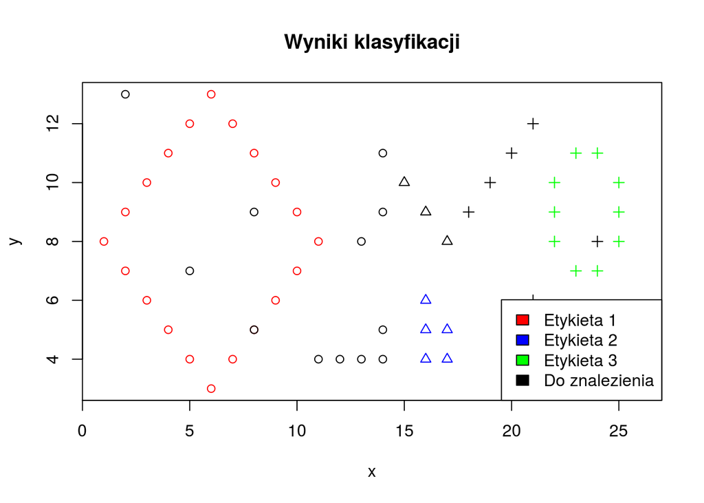

Porównajmy wyniki funkcji `knn` i `knn_do_porownan`:

| x | y | knn_wyn | knn_do_porownan_wyn |
| --- | --- | --- | --- |
| 2 | 13 | 1 | 1 |
| 5 | 7 | 1 | 1 |
| 8 | 9 | 1 | 1 |
| 14 | 11 | 1 | 1 |
| 13 | 4 | 1 | 1 |
| 8 | 5 | 1 | 1 |
| 21 | 6 | 3 | 3 |
| 24 | 8 | 3 | 3 |
| 26 | 4 | 3 | 3 |
| 14 | 9 | 1 | 1 |
| 13 | 8 | 1 | 1 |
| 15 | 10 | 2 | 2 |
| 16 | 9 | 2 | 2 |
| 17 | 8 | 2 | 2 |
| 18 | 9 | 3 | 3 |
| 19 | 10 | 3 | 3 |
| 20 | 11 | 3 | 3 |
| 21 | 12 | 3 | 3 |
| 14 | 4 | 1 | 1 |
| 14 | 5 | 1 | 1 |
| 11 | 4 | 1 | 1 |
| 12 | 4 | 1 | 1 |

## Odpowiedzi dla `p=Inf`, `k=18`

Klasyfikacja przebiegła w następujący sposób:

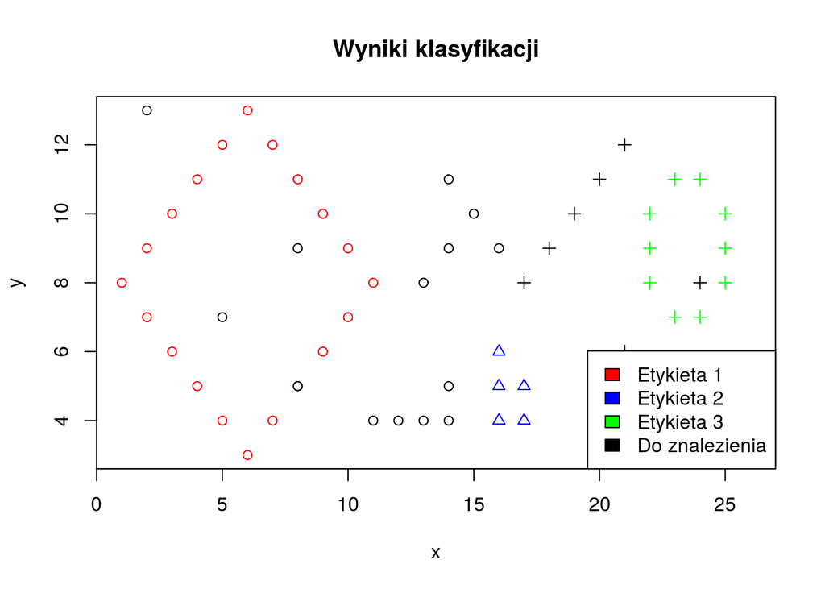

Porównajmy wyniki funkcji `knn` i `knn_do_porownan`:

| x | y | knn_wyn | knn_do_porownan_wyn |
| --- | --- | --- | --- |
| 2 | 13 | 1 | 1 |
| 5 | 7 | 1 | 1 |
| 8 | 9 | 1 | 1 |
| 14 | 11 | 1 | 1 |
| 13 | 4 | 1 | 1 |
| 8 | 5 | 1 | 1 |
| 21 | 6 | 3 | 3 |
| 24 | 8 | 3 | 3 |
| 26 | 4 | 3 | 3 |
| 14 | 9 | 1 | 1 |
| 13 | 8 | 1 | 1 |
| 15 | 10 | 1 | 1 |
| 16 | 9 | 1 | 1 |
| 17 | 8 | 3 | 3 |
| 18 | 9 | 3 | 3 |
| 19 | 10 | 3 | 3 |
| 20 | 11 | 3 | 3 |
| 21 | 12 | 3 | 3 |
| 14 | 4 | 1 | 1 |
| 14 | 5 | 1 | 1 |
| 11 | 4 | 1 | 1 |
| 12 | 4 | 1 | 1 |

Zauważmy, że ponieważ elementów z etykietą ,,trójkąt’‘jest mało, to przy dużym `k` te elementy ,,mało się liczą’‘i ich wpływ na wynik zostaje tłumiony do tego stopnia, że pomimo, że istnieją punkty ,,testowe’’, które są bardzo blisko trójkątów, to i tak nie zostają zakwalifikowane jako trójkąty.

A gdy weźmiemy już względnie bardzo dużą wartość `k`, to:

## Odpowiedzi dla `p=2`, `k=35`

Klasyfikacja przebiega w następujący sposób:

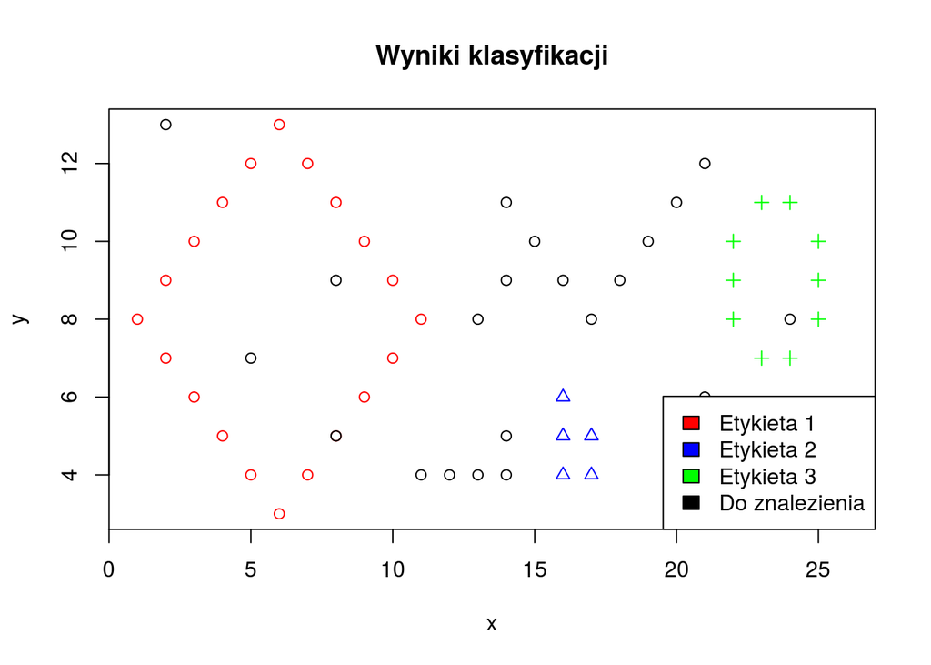

Jako że jest tutaj istotna przewaga elementów o etykiecie ,,kółko’’, to w przypadku wybrania zbyt dużego `k` wszystkie dane testowe otrzymają tę samą etykietę.

# Test 3 – dane testowe tożsame danym uczącym

Możliwe są $4$ kolory. Kolejne kolory na fragmencie wykresu funkcji sinus pojawiają się cyklicznie.

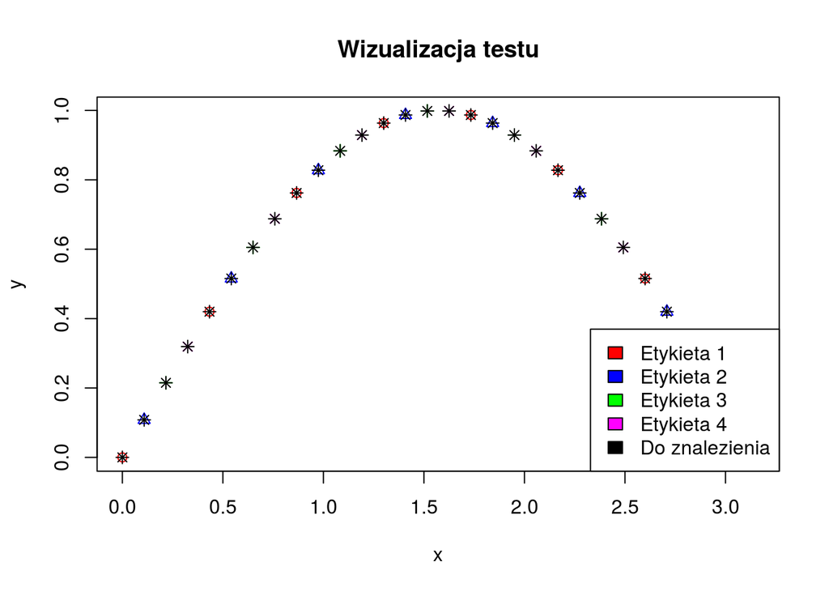

Sprawdźmy, czy klasyfikacja $1nn$ zadziała (np. dla $p = 2$) poprawnie:

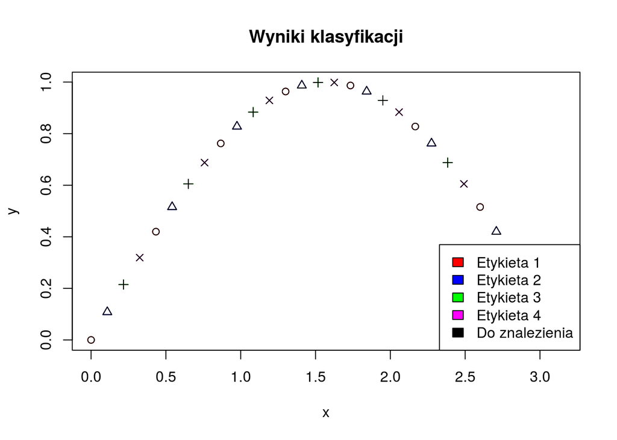

Porównajmy wyniki funkcji `knn` i `knn_do_porownan`:

| x | y | knn_wyn | knn_do_porownan_wyn |
| --- | --- | --- | --- |
| 0.0000000 | 0.0000000 | 1 | 1 |
| 0.1083308 | 0.1081190 | 2 | 2 |
| 0.2166616 | 0.2149704 | 3 | 3 |
| 0.3249923 | 0.3193015 | 4 | 4 |
| 0.4333231 | 0.4198891 | 1 | 1 |
| 0.5416539 | 0.5155539 | 2 | 2 |
| 0.6499847 | 0.6051742 | 3 | 3 |
| 0.7583155 | 0.6876995 | 4 | 4 |
| 0.8666462 | 0.7621621 | 1 | 1 |
| 0.9749770 | 0.8276890 | 2 | 2 |
| 1.0833078 | 0.8835120 | 3 | 3 |
| 1.1916386 | 0.9289767 | 4 | 4 |
| 1.2999694 | 0.9635500 | 1 | 1 |
| 1.4083002 | 0.9868265 | 2 | 2 |
| 1.5166309 | 0.9985334 | 3 | 3 |
| 1.6249617 | 0.9985334 | 4 | 4 |
| 1.7332925 | 0.9868265 | 1 | 1 |
| 1.8416233 | 0.9635500 | 2 | 2 |
| 1.9499541 | 0.9289767 | 3 | 3 |
| 2.0582848 | 0.8835120 | 4 | 4 |
| 2.1666156 | 0.8276890 | 1 | 1 |
| 2.2749464 | 0.7621621 | 2 | 2 |
| 2.3832772 | 0.6876995 | 3 | 3 |
| 2.4916080 | 0.6051742 | 4 | 4 |
| 2.5999387 | 0.5155539 | 1 | 1 |
| 2.7082695 | 0.4198891 | 2 | 2 |
| 2.8166003 | 0.3193015 | 3 | 3 |
| 2.9249311 | 0.2149704 | 4 | 4 |
| 3.0332619 | 0.1081190 | 1 | 1 |
| 3.1415927 | 0.0000000 | 2 | 2 |

Wszystkie wyniki zgadzają się.